# 2014年终总结

- 概述
- ttnet中文站改版
  - 改版原因
  - 准备工作
  - 项目工作
  - 运行情况
  - 个人成长
- 应用优化
  - 应用首页优化
  - 升级Maven
  - 多语言翻译优化
  - RPC梳理与优化

# 概述

在2014年，我的主要工作可以分为三个部分

- ttnet中文站改版
- 应用优化
- 中企培训

# ttnet中文站改版

## 改版原因

- ttnet中文站使用perl语言编写,结构混乱，应用不稳定，且已无人维护
- 大陆访问ttnet中文站会时不时的无法访问，2013年下半年情况更频繁
- 运维建议在大陆部署应用

## 准备工作

- 自学perl语言，从代码层梳理老站业务逻辑，并整理成文档，为后续迁移做好准备工作。期间兼顾处理一些老站问题
- 与运维、DBA讨论大陆部署应用的可行方案
- 评估技术风险，并考虑如何规避。尽可能降低后续开发中遇到的风险
- 调整现行开发框架，以适应中文站开发。包括去反射，提升性能，添加消息队列支持
- 与项目组讨论确认开发规范

## 项目工作

- 由于版本较大，对版本进行了阶段性划分，分三期完成
- 制定每期的计划，每日晨会跟踪执行，如有问题及时调整
- 期间负责询报价的代码开发工作
- 开发应用通用组件：简繁通，redis缓存，HtmlEncode
- 7月，项目组经历30多小时发布，中文站上线。目前运行良好

## 运行情况

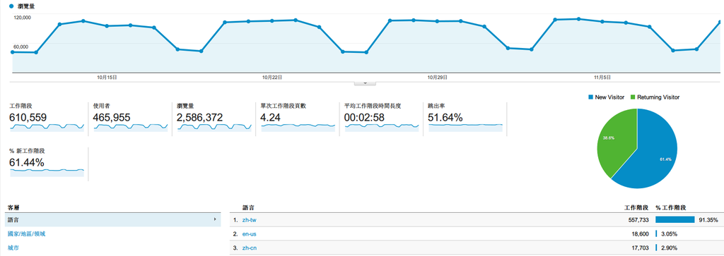

## 个人成长

- 培养了风险预判及规避风险的能力
- 锻炼了对于大版本执行的把控能力
- 包括每个开发人员的任务划分，进度管理和突发事件的处理能力
- 以及多部门协作的协调能力

# 应用优化

- 应用首页优化
- 构建工具Maven升级
- 多语言翻译优化
- RPC梳理与优化

## 应用首页优化

- 对国际站，中文站，多语言首页进行了优化
- 提高服务器响应时间，合并js、css,gzip压缩，页面缓存,redis缓存
- 优化后，台湾响应时间在100ms左右，页面加载时间在1.5s左右。大陆大部分响应时间在300ms左右,页面加载时间2.5s左右

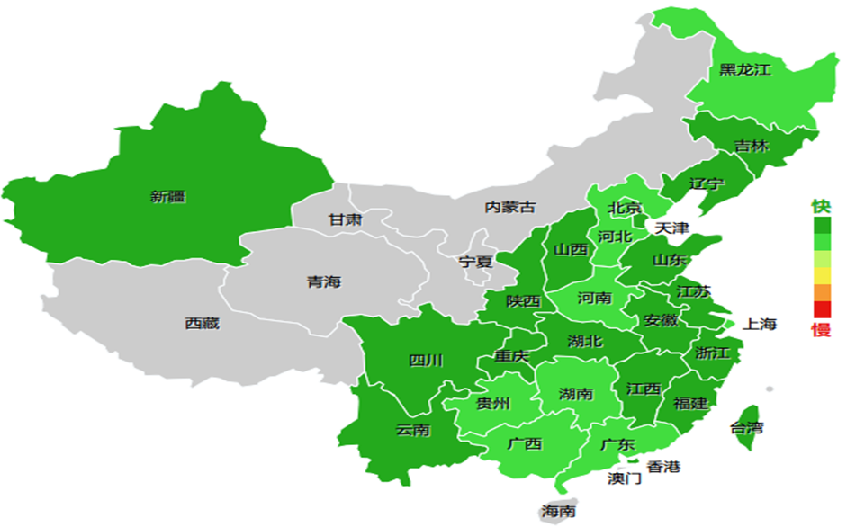

## 升级Maven

- 升级Maven2->Maven3
- 方便最新构建插件的使用

## 多语言翻译优化

- 翻译流程优化，从数据库层面提高翻译效率
- 修改翻译数据结构，从数据结构层面提高翻译效率
- 40台虚拟机->10台虚拟机

## RPC梳理与优化

- 调用混乱
- 耦合紧密
- 无容错

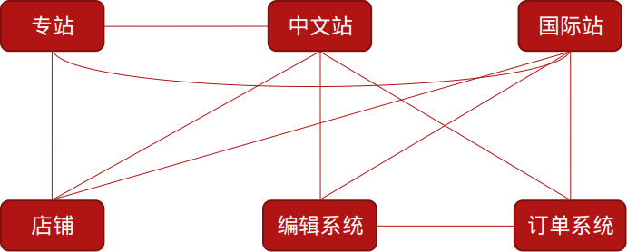